# Fitting Conditional and Simultaneous Autoregressive Spatial Models in hglm

Moudud Alam

Statistics, School of Technology and Business Studies, Dalarna University

Lars ård

Statistics, School of Technology and Business Studies, Dalarna University

Xia Shen

Department of Medical Epidemiology and Biostatistics, Karolinska Institutet

2015-09-09

Abstract

We present a new version ($\geqslant 2.0$) of the *hglm* package for fitting hierarchical generalized linear models (HGLMs) with spatially correlated random effects. `CAR()` and `SAR()` families for conditional and simultaneous autoregressive random effects were implemented. Eigen decomposition of the matrix describing the spatial structure (e.g., the neighborhood matrix) was used to transform the CAR/SAR random effects into an independent, but heteroscedastic, Gaussian random effect. A linear predictor is fitted for the random effect variance to estimate the parameters in the CAR and SAR models. This gives a computationally efficient algorithm for moderately sized problems.

# Introduction

We present an algorithm for fitting spatial generalized linear models with conditional and simultaneous autoregressive [CAR & SAR; Besag (1974); Cressie (1993)] random effects. The algorithm completely avoids the need to differentiate the spatial correlation matrix by transforming the model using an eigen decomposition of the precision matrix. This enables the use of already existing methods for hierarchical generalized linear models [HGLMs; Y. Lee and Nelder (1996)] and this algorithm is implemented in the latest version ($\geqslant$ 2.0) of the [*hglm*](https://CRAN.R-project.org/package=hglm) package (Rönnegård, Shen, and Alam 2010).

The *hglm* package, up to version 1.2-8, provides the functionality for fitting HGLMs with uncorrelated random effects using an extended quasi likelihood method [EQL; Y. Lee, Nelder, and Pawitan (2006)]. The new version includes a first order correction of the fixed effects based on the current EQL fitting algorithm, which is more precise than EQL for models having non-normal outcomes (W. Lee and Lee 2012). Similar to the h-likelihood correction of Noh and Lee (2007), it corrects the estimates of the fixed effects and thereby also reduces potential bias in the estimates of the dispersion parameters for the random effects (variance components). The improvement in terms of reduced bias is substantial for models with a large number of levels in the random effect (Noh and Lee 2007), which is often the case for spatial generalized linear mixed models (GLMMs).

Earlier versions of the package allow modeling of the dispersion parameter of the conditional mean model, with fixed effects, but not the dispersion parameter(s) of the random effects. The current implementation, however, enables the user to specify a linear predictor for each dispersion parameter of the random effects. Adding this option was a natural extension to the package because it allowed implementation of our proposed algorithm that fits CAR and SAR random effects.

Though the CAR/SAR models are widely used for spatial data analysis there are not many software packages which can be used for their model fitting. GLMMs with CAR/SAR random effects are often fitted in a Bayesian way using BUGS software [e.g., WinBUGS; Lunn et al. (2000) or alike], which leads to extremely slow computation due to its dependence on Markov chain Monte Carlo simulations. The R package *INLA* (Martins et al. 2013) provides a relatively fast Bayesian computation of spatial HGLMs via Laplace approximation of the posterior distribution where the model development has focused on continuous domain spatial modeling (Lindgren and Rue 2015) whereas less focus has been on discrete models including CAR and SAR. Recently, package [*spaMM*](https://CRAN.R-project.org/package=spaMM) (Rousset and Ferdy 2014) was developed to fit spatial HGLMs but is rather slow even for moderately sized data. Here, we extend package *hglm* to also provide fast computation of HGLMs with CAR and SAR random effects and at the same time an attempt has been made to improve the accuracy of the estimates by including corrections for the fixed effects.

The rest of the paper is organized as follows. First we give an introduction to CAR and SAR structures and present the h-likelihood theory together with the eigen decomposition of the covariance matrix of the CAR random effects and show how it simplifies the computation of the model. Then we present the R implementation, show the use of the implementation for two real data examples and evaluate the package using simulations. The last section concludes the article.

# CAR and SAR structures in HGLMs

HGLMs with spatially correlated random effects are commonly used in spatial data analysis (Cressie 1993; Wall 2004). A spatial HGLM with Gaussian CAR random effects is given by

$$\begin{aligned}
\label{eq:1}
& E\left(z_s | u_s\right) \quad && = && \quad \mu_s,
\quad \quad \quad \quad \quad s = 1,2,\ldots,n, \nonumber\\
& g\left(\mu_s\right) \quad = \quad \eta_s \quad && =
&& \quad \mathbf{X}_s\mathbf{\beta} + \mathbf{Z}_s u_s,
\end{aligned} (\#eq:1)$$

$$\label{eq:2}
z_s|u_s \sim Exponential~Family, (\#eq:2)$$

with $z_s|u_s \perp z_t|u_t$, $\forall s \ne t$ and

$$\label{eq:3}
\mathbf{u} = \left(u_1 , u_2 , \dots , u_n\right)^{T} \sim
N\left(\mathbf{0}, \Sigma =
\tau\left(\mathbf{I}-\rho\mathbf{D}\right)^{-1}\right), (\#eq:3)$$

where $s$ represents a location identified by the coordinates $\left(x\left(s\right),y\left(s\right)\right)$, $\mathbf{\beta}$ is a vector of fixed effects, $\mathbf{X}_s$ is the fixed-effect design matrix for location $s$, $u_s$ is the location-specific random effects and $\mathbf{Z}_s$ is a design matrix associated with $u_s$. While

$$\label{eq:3b}
\mathbf{u} = \left(u_1 , u_2 , \dots , u_n\right)^{T} \sim
N\left(\mathbf{0}, \Sigma =
\tau\left(\mathbf{I}-\rho\mathbf{D}\right)^{-1}\left(\mathbf{I}-\rho\mathbf{D}^{T}\right)^{-1}\right) (\#eq:3b)$$

gives a Gaussian SAR random effects structure. The $\mathbf{D}$ matrix in Equations (@ref(eq:3)) and (@ref(eq:3b)) is some known function of the location coordinates (see, e.g., Clayton and Kaldor 1987) and $\rho$ is often referred to as the spatial dependence parameter (Hodges 2013). In application, $\mathbf{D}$ is often a neighborhood matrix whose diagonal elements are all 0, and off-diagonal elements $\left(s, t\right)$ are 1 if locations $s$ and $t$ are neighbors.

If $\mathbf{\Sigma}=\tau \mathbf{I}$, i.e., there is no spatial correlation, then this model may be estimated by using usual software packages for GLMMs. With $\mathbf{\Sigma}=\tau \mathbf{D}$, i.e., defining the spatial correlation directly via the $\mathbf{D}$ matrix, the model can be fitted using earlier versions of the *hglm* package. However, for the general structure in Equations (@ref(eq:3)) and (@ref(eq:3b)), estimation using explicit maximization of the marginal or profile likelihood involves quite advanced derivations as a consequence of partial differentiation of the likelihood including $\mathbf{\Sigma}$ with $\rho$ and $\tau$ as parameters (see, e.g., W. Lee and Lee 2012). In this paper, we show that by using eigen decomposition of $\mathbf{\Sigma}$, we can modify an already existing R package, e.g., *hglm*, with minor programming effort, to fit a HGLM with CAR or SAR random effects.

# h-likelihood estimation

In order to explain the specific model fitting algorithm implemented in *hglm*, we present a brief overview of the EQL algorithm for HGLMs (Y. Lee and Nelder 1996). First, we start with the standard HGLM containing only uncorrelated random effects. Then, we extend the discussion for CAR and SAR random effects. Though it is possible to have more than one random-effect term, in a HGLM, coming from different distributions among the conjugate distributions to GLM families, for presentational simplicity we consider only one random-effect in this section. The (log-)h-likelihood for a HGLM with independent random effects can be presented as

$$\label{eq:3c}
h = \sum_i\sum_j \left( \frac{\left( y_{i,j} \theta_{i,j} - b\left(
\theta_{i,j} \right) \right)}{\phi} +c\left( y_{i,j},\phi \right)
\right)+ \sum_i\left( \frac{\psi v_i - b_R \left( v_i \right)}{\tau}
+c_R\left(\tau \right) \right), (\#eq:3c)$$

where, $i = 1, 2, \dots, n$, $j=1,2,\dots k$, $\theta$ is the canonical parameter of the mean model, $\phi$ is the dispersion parameter of th mean model, $b\left(. \right)$ a function which satisfies $E\left( y_{i,j}|u_i \right)=\mu_{i,j}=b'\left( \theta_{i,j} \right)$ and $Var\left( y_{i,j}|u_i \right)=\phi b''\left( \theta_{i,j} \right) = \phi V\left( \mu_{i,j} \right)$, where $V(.)$ is the GLM variance function. Furthermore, $\phi$ is the dispersion parameter of the mean model, $\theta_R\left( u_i \right)=v_i$ with $\theta_R\left( . \right)$ being a so-called weak canonical link for $u_i$ (leading to conjugate HGLMs) or an identity link for Gaussian random effects leading to GLMMs (Y. Lee, Nelder, and Pawitan 2006, 3–4), $\psi = E\left( u_i \right)$, $\tau$ is the dispersion parameter, and $b_R$ and $c_R$ are some known functions depending on the distribution of $u_i$. Equation (@ref(eq:3c)) also implies that $h$ can be defined uniquely by using the means and the mean-variance relations of $y_{i,j}|u_i$ and the quasi-response $\psi$, allowing us representing it as a sum of two extended quasi-likelihoods [double EQL; Y. Lee and Nelder (2003)] as

$$\label{eq:3d}
-2D = \sum_i\sum_j \left( \frac{d_{0,i,j}}{\phi} + \log\left( 2\pi \phi
V\left( y_{i,j}|u_i\right)\right)\right) + \sum_i \left(
\frac{d_{1,i}}{\tau}+ \log\left( 2\pi\tau V_1\left(
u_i\right)\right)\right), (\#eq:3d)$$

where $d_{0,i,j}$ and $d_{1,i}$ are the deviance components of $y_{i,j}|u_i$ and $\psi$ respectively and $Var\left( \psi \right)= \tau V_1\left( u_i\right)$. It is worth noting that $-2D$ is an approximation to $h$ if $y|u$ or $u$ (or both) belongs/belong to Binomial, Poisson, double-Poisson (or quasi-Poisson), Beta, or Gamma families. However, no such equivalent relation (even approximately) is known for the quasi-Binomial family.

In order to estimate the model parameters, (Y. Lee and Nelder 1996) suggested a two-step procedure in which the first, for fixed dispersion parameters $\phi$ and $\tau$, $h$ (or equivalently $-2D$) is maximized w.r.t. $\mathbf{\beta}$ and $\mathbf{v}=\lbrace v_i \rbrace$. This maximization leads to an iteratively weighted least-square (IWLS) algorithm which solves
$$\mathbf{T}_{a}^{\prime}\mathbf{\Sigma}^{-1}\mathbf{T}_{a}\boldsymbol{\delta}=\mathbf{T}_{a}^{\prime}\mathbf{\Sigma}^{-1}\mathbf{y}_{a},$$
where $\mathbf{T}_{a}=\begin{pmatrix} \mathbf{X} & \mathbf{Z}\\ \mathbf{0} & \mathbf{I}_{n}\end{pmatrix}$, $\boldsymbol{\delta} = \begin{pmatrix} \mathbf{\beta} \\ \mathbf{v} \end{pmatrix}$, $\mathbf{y_a}= \begin{pmatrix} \mathbf{y}_{0,a}\\ \mathbf{y}_{1,a} \end{pmatrix}$ with $\mathbf{y}_{0,a}=\left\lbrace \eta_{i,j} -\left( y_{i,j} - \mu_{i,j}\right)\frac{\partial \eta_{i,j}}{\partial \mu_{i,j}}\right\rbrace$ and $\mathbf{y}_{1,a}=\left \lbrace v_i - \left( \psi_i - u_i\right) \frac{\partial v_i}{\partial u_i}\right \rbrace$ are the vectors of GLM working responses for $y_{i,j}|u_i$ and $v_i$ respectively, and $\mathbf{\Sigma} = \mathcal{I}\mathbf{W}^{-1}$ with $\mathcal{I}$ being a diagonal matrix whose first $n$ diagonal elements are all equal to $\phi$ and the remaining $k$ diagonal elements are all equal to $\tau$ and $\mathbf{W}=\text{diag}\left( \mathbf{w}_{0},\mathbf{w}_1 \right)$ where $\mathbf{w}_0 = \left\lbrace \left( \frac{\partial \mu_{i,j}}{\partial \eta_{i,j}} \right)^2 \frac{1}{V\left( \mu_{i,j}\right)} \right\rbrace$ and $\mathbf{w}_1= \left\lbrace \left(\frac{\partial u_i}{\partial v_i}\right)^2 \frac{1}{V_1\left(u_i \right)} \right\rbrace$.

In the second step, the following profile likelihood is maximized to estimate the dispersion parameters.

$$\label{eq:3e}
p_{\mathbf{\beta}, \mathbf{v}} \left( h \right) = \left( h - \frac{1}{2}
\left|\frac{\partial^2 h}{\partial\left(\mathbf{\beta},\mathbf{v}\right)
\partial\left(\mathbf{\beta},\mathbf{v}\right)^T }
\right|\right)_{\mathbf{\beta}=\hat{\mathbf{\beta}}, \mathbf{v} =
\hat{\mathbf{v}}}, (\#eq:3e)$$

where $\hat{\mathbf{\beta}}$ and $\hat{\mathbf{v}}$ are obtained from the fist step. One needs to iterate between the two steps until convergence. This procedure is often referred to as “HL(0,1)” (W. Lee and Lee 2012) and is available in the R packages *spaMM* and [*HGLMMM*](https://CRAN.R-project.org/package=HGLMMM) (Molas and Lesaffre 2011). Because there is no unified algorithm to maximize $p_{\mathbf{\beta}, \mathbf{v}}$ computer packages often carry out the maximization by using general purpose optimization routines, e.g., package *spaMM* uses the `optim` function.

A unified algorithm for estimating the variance components can be derived by using profile likelihood adjustment in Equation (@ref(eq:3d)) instead of (@ref(eq:3c)). This leads to maximizing

$$\label{eq:3f}
p_{\mathbf{\beta}, \mathbf{v}} \left( Q \right) = \left( -2D -
\frac{1}{2} \left|\frac{\partial^2
\left(-2D\right)}{\partial\left(\mathbf{\beta},\mathbf{v}\right)
\partial\left(\mathbf{\beta},\mathbf{v}\right)^T }
\right|\right)_{\mathbf{\beta}=\hat{\mathbf{\beta}}, \mathbf{v} =
\hat{\mathbf{v}}} (\#eq:3f)$$

for estimating $\tau$ and $\phi$. The corresponding score equation of the dispersion parameters, after ignoring the fact that $\hat{\mathbf{\beta}}$ and $\hat{\mathbf{v}}$ are functions of $\phi$ and $\tau$, can be shown (see, e.g., Y. Lee and Nelder 2001) to have the form of Gamma family GLMs with $d_{0,i,j}/\left( 1-h_{i,j} \right)$ and $d_{1,i}/\left( 1-h_{i} \right)$ as the responses for $\phi$ and $\tau$ respectively, where $h_{i,j}$ and $h_i$ are the hat values corresponding to $y_{i,j}$ and $v_i$ in the first step, and $\left( 1-h_{i,j} \right)/2$ and $\left( 1-h_{i} \right)/2$ as the respective prior weights. This procedure is often referred to as EQL (Y. Lee, Nelder, and Pawitan 2006) or DEQL (Y. Lee and Nelder 2003) and was the only available procedure in *hglm* ($\leqslant$ 1.2-8). An advantage of this algorithm is that fixed effects can also be fitted in the dispersion parameters (Y. Lee, Nelder, and Pawitan 2006) without requiring any major change in the algorithm.

HL(0,1) and EQL were found to be biased, especially for binary responses when the cluster size is small (Y. Lee and Nelder 2001; Noh and Lee 2007) and when $\tau$ is large in both Binomial and Poisson GLMMs. Several adjustments are suggested and explained in the literature (see, e.g., Y. Lee and Nelder 2001, 2003; W. Lee and Lee 2012) to improve the performance of h-likelihood estimation. Among these alternative suggestions HL(1,1) is the most easily implementable and found to be computationally faster than the other alternatives (W. Lee and Lee 2012). The HL(1,1) estimates the fixed effects, $\mathbf{\beta}$, by maximizing $p_{\mathbf{v}}\left( h \right)$ instead of $h$ and can be implemented by adjusting the working response $\mathbf{y}_a$ in the IWLS step, according to W. Lee and Lee (2012). In *hglm* ($\geqslant$ 2.0), this correction for the $\mathbf{\beta}$ estimates has been implemented, through the `method = "EQL1"` option, but still $p_{\mathbf{\beta}, \mathbf{v}} \left( Q \right)$ is maximized for the estimation of the dispersion parameters, in order to make use of the unified algorithm for dispersion parameter estimates via Gamma GLMs. Table 1 shows available options for h-likelihood estimation (subject to the corrections mentioned above) in different R packages.

Table 1: Implemented h-likelihood methods in *hglm* compared to *spaMM* and *HGLMMM* packages.

|  | *hglm* | *spaMM* | *HGLMMM* |
| --- | --- | --- | --- |
| EQL | `method = "EQL"` | `HLmethod = "EQL-"` | - |
| HL(0,1) | - | `HLmethod = "HL(0,1)"` | `LapFix = FALSE` |
| HL(1,1) | $^{\text{a}}$ | `HLmethod = "HL(1,1)"` | `LapFix = TRUE` |

$^{\text{a}}$ By specifying `method = "EQL1"` in the *hglm* package, the HL(1,1) correction of the working response is applied in the EQL algorithm.

The above EQL method cannot be directly applied to HGLMs with CAR/SAR random effects because the resulting $p_{\mathbf{\beta}, \mathbf{v}} \left( Q \right)$ does not allow us to use the Gamma GLM to estimate the dispersion parameters, $\tau$ and $\rho$. In the following subsection we present a simplification which allows us to use the Gamma GLM for estimating $\tau$ and $\rho$.

## Simplification of model computation

The main difference between an ordinary GLMM with independent random effects and CAR/SAR random effects models is that the random effects in the later cases are not independent. In the following we show that by using the eigen decomposition we can reformulate a GLMM with CAR or SAR random effects to an equivalent GLMM with independent but heteroscedastic random effects.

**Lemma 1**

Let $\mathbf{\omega} = \{\omega_i\}_{i=1}^{n}$ be the eigenvalues of $\mathbf{D}$, and $\mathbf{V}$ is the matrix whose columns are the corresponding orthonormal eigenvectors, then

$$\label{eq:4}
\frac{1}{\tau} ( \mathbf{I} - \rho \mathbf{D} ) = \mathbf{V}
\mathbf{\Lambda} \mathbf{V}^{T}, (\#eq:4)$$
where $\mathbf{\Lambda}$ is diagonal matrix whose $i$th diagonal element is given by

$$\lambda_i = \frac{1-\rho
\omega_i}{\tau}.$$

**Proof of Lemma 1**

$$\begin{aligned}
& \mathbf{V} \mathbf{\Lambda} \mathbf{V}^{T} \quad && =
\quad && \mathbf{V}\text{diag}\left\lbrace \frac{1-\rho
\omega_i}{\tau} \right \rbrace \mathbf{V}^{T} \nonumber\\
&\quad && = \quad && \frac{1}{\tau} (
\mathbf{V} \mathbf{V}^{T} - \rho \mathbf{V} \text{diag}\{ \omega_i \}
\mathbf{V}^{T} ) \nonumber\\
&\quad && = \quad && \frac{1}{\tau} ( \mathbf{I}
- \rho \mathbf{D} )
\end{aligned}$$

It is worth noting that the relation between the eigenvalues of $\mathbf{D}$ and $\mathbf{\Sigma}$ was already known as early as in Ord (1975) and was used to simplify the likelihood function of the Gaussian CAR model. Similarly, for simplification of the SAR model, we have
$$\frac{1}{\tau} ( \mathbf{I} - \rho \mathbf{D} )(
\mathbf{I} - \rho \mathbf{D}^{T} ) = \mathbf{V} \text{diag}\left\{
\frac{(1-\rho \omega_i)^{2}}{\tau}\right\} \mathbf{V}^{T}.$$
An anonymous referee has pointed out that a somewhat extended version of **Lemma 1**, which deals with simultaneous diagonalization of two positive semi-definite matrices (Newcomb 1969), has already been used to simplify the computation of Gaussian response models with intrinsic CAR random effects, especially in a Bayesian context Hodges (2013). Therefore, **Lemma 1** is not an original contribution of this paper, however, to the authors’ knowledge, no software package has yet utilized this convenient relationship to fit any HGLM by using interconnected GLMs, as discussed below.

Re-arranging Equation (@ref(eq:1)), we have

$$\label{eq:5}
\mathbf{\eta} = \mathbf{X} \mathbf{\mathbf{\beta}} + \tilde{\mathbf{Z}}
\mathbf{u}^{\ast}, (\#eq:5)$$

where, $\mathbf{\eta} = \left\lbrace \eta_s \right\rbrace$, $\mathbf{X} = \left\lbrace \mathbf{X}_s \right\rbrace$, $\tilde{\mathbf{Z}} = \left\lbrace \mathbf{Z}_s \right\rbrace \mathbf{V}$ and $\mathbf{u}^{\ast} = \mathbf{V}^{T} \mathbf{u}$. With the virtue of **Lemma 1** and the properties of the multivariate normal distribution, we see that $\mathbf{u}^{\ast} \sim N\left(\mathbf{0}, \mathbf{\Lambda}^{-1}\right)$. This model can now easily be fitted using the *hglm* package in R. Further note that, for the CAR model, from **Lemma 1**, we have

$$\begin{aligned}
\label{eq:6a}
& \lambda_i \quad && = && \quad \frac{1-\rho
\omega_i}{\tau} \nonumber \\
&\quad && = \quad && \quad \theta_0 + \theta_1
\omega_i
\end{aligned} (\#eq:6a)$$

where $\theta_0 = 1/\tau$ and $\theta_1 = - \rho/\tau$. While for the SAR model,

$$\begin{aligned}
\label{eq:6b}
&\quad && \lambda_i \quad && = && \quad
\frac{(1-\rho \omega_i)^{2}}{\tau} \nonumber \\
&\Rightarrow \quad && \sqrt{\lambda_{i}} \quad &&
= && \quad \theta_0 + \theta_1 \omega_i,
\end{aligned} (\#eq:6b)$$

where $\theta_0 = 1/\sqrt{\tau}$ and $\theta_1 = - \rho/\sqrt{\tau}$. Following (Y. Lee, Nelder, and Pawitan 2006), we can use an inverse link for CAR or an inverse square-root link for SAR in a Gamma GLM with response ${u_i}^{*2}/\left( 1- h_i\right)$, where $h_i$ is the corresponding hat value from the mean model (Equation (@ref(eq:5))), $\left( 1-h_i\right)/2$ as the weight and the linear predictor given by Equations (@ref(eq:6a)) and (@ref(eq:6b)) to obtain an EQL estimate of $\theta_0$ and $\theta_1$.

# Implementation

The spatial models above are implemented in the *hglm* package ($\geqslant2.0$) by defining new families, `CAR()` and `SAR()`, for the random effects. The “CAR” and “SAR” families allow the user to define spatial structures by specifying the $\mathbf{D}$ matrix. Using **Lemma 1**, these families are created using $\mathbf{D}$ with default link function “identity” for the Gaussian random effects $\mathbf{u}$, and “inverse” and “inverse.sqrt” for the dispersion models (@ref(eq:6a)) and (@ref(eq:6b)). When the “CAR” or “SAR” family is specified for the random effects, the parameter estimates $\hat{\rho}$ and $\hat{\tau}$ are given in the output in addition to the other summary statistics of the dispersion models. The new input options in *hglm* are described in Table 2.

Throughout the examples below, we use Gaussian CAR random effects to introduce spatial correlation. However, one can also add additional independent non-Gaussian random effects along with the Gaussian CAR random effect. For example, an overdispersed count response can be fitted using a Poisson HGLM with an independent Gamma and Gaussian CAR random effects.

Table 2: New options in the `hglm` function.

| Option | Explanation |
| --- | --- |
| `rand.family = CAR(D = nbr)` | The random effect has conditional or simul- |
| `rand.family = SAR(D = nbr)` | taneous autoregressive covariance structure. |
|  | Here `nbr` is a matrix provided by the user. |
| `method = "EQL1"` | The first order correction of fixed effects |
|  | (W. Lee and Lee 2012) applied on the EQL estimates. |
| `rand.disp.X = X` | Linear predictor for the variance component |
|  | of a random effect. The matrix `X` is provided |
|  | by the user. |
| `rand.family =` | This option provides the possibility of having |
| `list(Gamma(),CAR())` | different distributions for the random effects. |

# Examples and simulation study

In the *hglm* package vignette, we look at the improvement of EQL1 in comparison to EQL. Here, we focus on the precision of the parameter estimates with spatial HGLMs.

## Poisson CAR & SAR model

We study the properties of the estimates produced by *hglm* using a simulation study built around the Scottish Lip Cancer example (see also the examples). We simulate data with the same $\mathbf{X}$ values, offset and neighborhood matrix as in the Scottish Lip Cancer example data. We use the true values of the parameters, after W. Lee and Lee (2012), as $\left(\text{intercept}, \mathbf{\beta}_{fpp}, \tau, \rho \right) = \left( 0.25, 0.35, 1.5, 0.1 \right)$. The parameter estimates for 1000 Monte Carlo iterations are summarized in Table 3.

Table 3: Average bias in parameter estimates in the simulation using the Scottish Lip Cancer example.

|  |  | Bias in the estimation methods |  |  |  |  |
| --- | --- | --- | --- | --- | --- | --- |
| 3-7 Parameter | True value | CAR |  |  | SAR |  |
| 3-4 |  | EQL$^{\dagger}$ | EQL1 correction$^{\dagger}$ |  | EQL$^{\dagger}$ | EQL1 correction$^{\dagger}$ |
| intercept | 0.2500 | 0.0351$^\ast$ | 0.0105* |  | 0.0541$^\ast$ | 0.0307* |
| $\mathbf{\beta}_{fpp}$ | 0.3500 | $-0.0018^\ast$ | $-0.0004$* |  | $-0.0034^\ast$ | $-0.0022$* |
| $1 / \tau$ | 0.6667 | 0.0660$^\ast$ | 0.0658$^\ast$ |  | n/a* | n/a* |
| $-\rho/\tau$ | $-0.0667$ | 0.0118$^\ast$ | 0.0119$^\ast$ |  | n/a* | n/a* |
| $1 /\sqrt{\tau}$ | 0.8165 | n/a* | n/a* |  | 0.0393$^\ast$ | 0.0370$^\ast$ |
| $-\rho/\sqrt{\tau}$ | $-0.0817$ | n/a* | n/a* |  | 0.0037$^\ast$ | 0.0049$^\ast$ |
| $\tau$ | 1.5000 | $-0.0770^\ast$ | $-0.0760^\ast$ |  | $-0.0880^\ast$ | $-0.0860^\ast$ |
| $\rho$ | 0.1000 | $-0.0247^\ast$ | $-0.0250^\ast$ |  | $-0.0097^\ast$ | $-0.0102^\ast$ |
| $^\ast$ Significantly different from 0 at the 5% level. |  |  |  |  |  |  |
| $^{\dagger}$ The estimates are the means from 1000 replicates. |  |  |  |  |  |  |

Both the EQL and the EQL1 correction are slightly biased for $\tau$ and $\rho$ (Table 3) though the absolute amount of bias is small and may be negligible in practical applications. The EQL1 correction mainly improves the estimates of the intercept term. There were convergence problems for a small number of replicates, which was not surprising given the small number of observations ($n=56$) and that the simulated value for the spatial autocorrelation parameter $\rho$ connects the effects in the different Scottish districts rather weakly. Such convergence problems can be addressed by pre-specifying better starting values. For the converged estimates the bias was small and negligible.

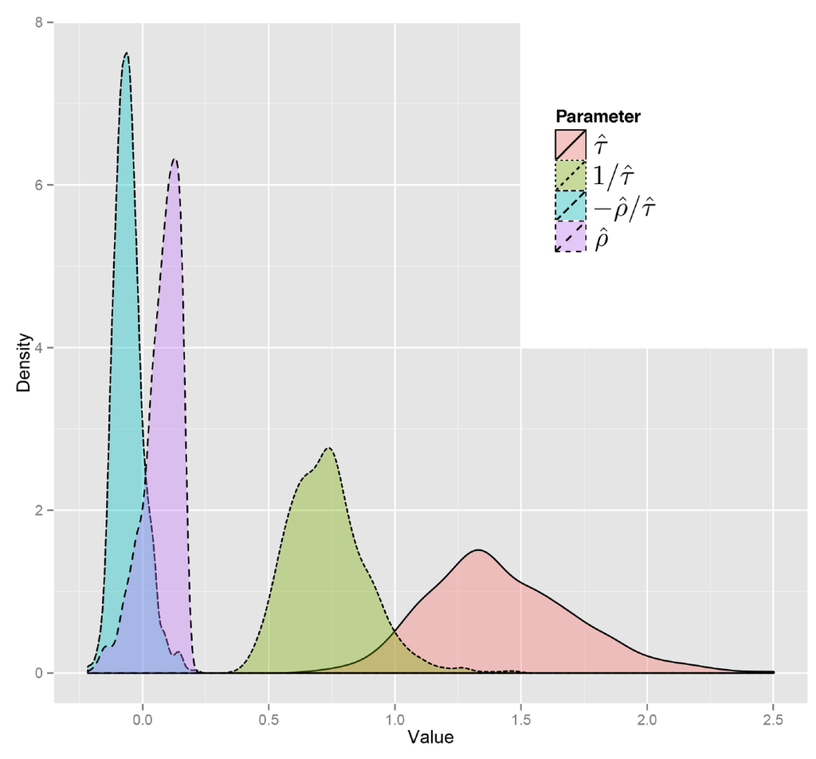

Figure 1: Density plot of the spatial variance-covariance parameter estimates from CAR models via `"EQL1"` over 1000 Monte Carlo simulations for the Scottish Lip Cancer example.

The simulation results also revealed that the distribution of $\hat{\rho}$ from CAR models is skewed (see Figure 1), which was also pointed out by W. Lee and Lee (2012). However, the distribution of $-\hat{\rho}/\hat{\tau}$ turned out to be less skewed than the distribution of $\hat{\rho}$. Similar observation was also found for SAR models. This suggests, we might draw any inference on spatial variance-covariance parameters in the transformed scale, $\theta_0$ and $\theta_1$.

## Computational efficiency

Fitting CAR and SAR models for large data sets could be computationally challenging, especially for the spatial variance-covariance parameters. Using our new algorithm in *hglm*, moderately sized problems can be fitted efficiently.

We re-sampled from the `ohio` data set (for more details on the data set see also the examples) for different number of locations, each with 10 replicates, executed on a single Intel©Xeon©E5520 2.27GHz CPU. In each replicate, the data was fitted using both *hglm* and *spaMM*, for the same model described above. The results regarding average computational time are summarized in Figure 2. *hglm* is clearly more usable for fitting larger sized data sets. In the package vignette, we also show the comparisons of the parameter estimates, where the `"EQL"` estimates from *hglm* are almost identical to the `"EQL-"` estimates from *spaMM*, with high correlation coefficients between the two methods: 1.0000, 0.9998, 0.9997 and 0.9999 for the residual variance, $\rho$, $\tau$ and the intercept, respectively.

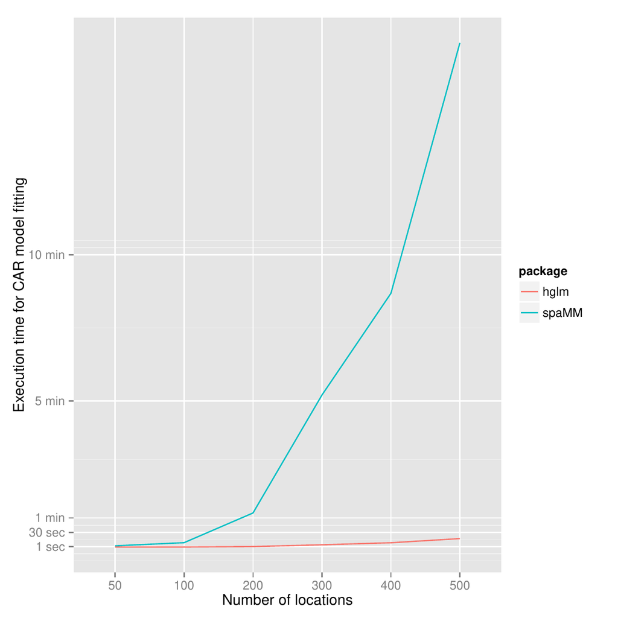

Figure 2: Comparison of the execution time for fitting CAR models using *hglm* and *spaMM*.